# B2: Air Plume

Αντώνιος Νεκτάριος Ντουντούκαλης

08 December, 2024

Μάθημα: Γεωγραφική Ανάλυση

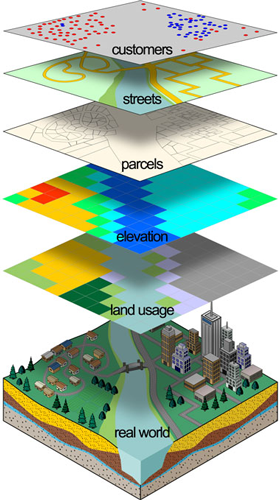

## 1 Ερώτημα 1: Πληθυσμός

Πόσα άτομα επηρεάζονται από την έκθεση σε επίπεδο 7500 ng; Πού βρίσκονται οι πληγείσες πόλεις;

> Επιλογή ολων των οικισμών με μόλυνση >= 7500.

```r
oik$ActualPollution = terra::extract(ActualPollution, oik, ID=F)[[1]]
oik2 = subset(oik, ActualPollution >= TheThreshold)
dim(oik2)
```

```
## [1] 16 13
```

Υπάρχουν 16 οικισμοί με έκθεση σε μόλυνση >= 7500. Άθροισμα πληθυσμού:

```r
sum(oik2$pop2011)
```

```
## [1] 7294
```

Οπτικοποιηση των 16 οικισμών με συνολικό πληθυσμό 7294 κατοίκους.  
**Χάρτης 1.1**

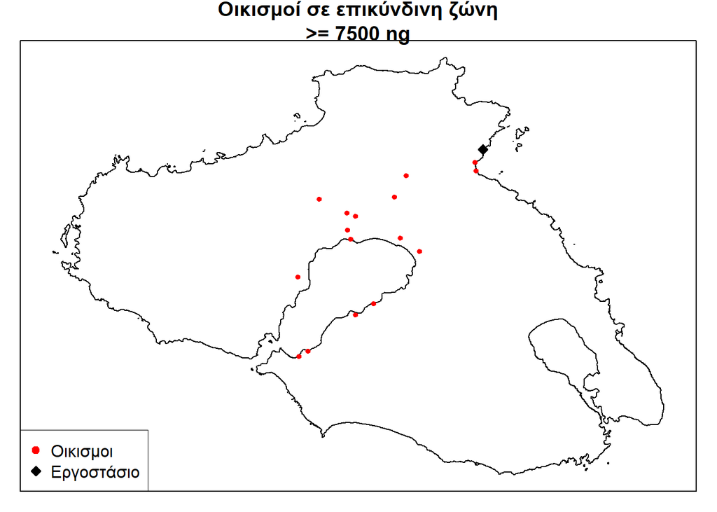

```r
par(mar=c(1,1,2,1) )
plot(st_geometry(acto), main=sprintf("Οικισμοί σε επικύνδινη ζώνη\n>= %s ng",TheThreshold) )
plot(st_geometry(oik2), main="Towns", pch=19, cex=0.6, col="red", add=T)
plot(st_geometry(nuclear), add=T, pch=23, bg="black", col="black")
legend(x='bottomleft', pch=c(19,23), legend=c("Οικισμοι","Εργοστάσιο"),
       col=c("red","black"), pt.bg="black", bg=NULL, box.lwd=0)
box()
```

**Χάρτης 1.2**

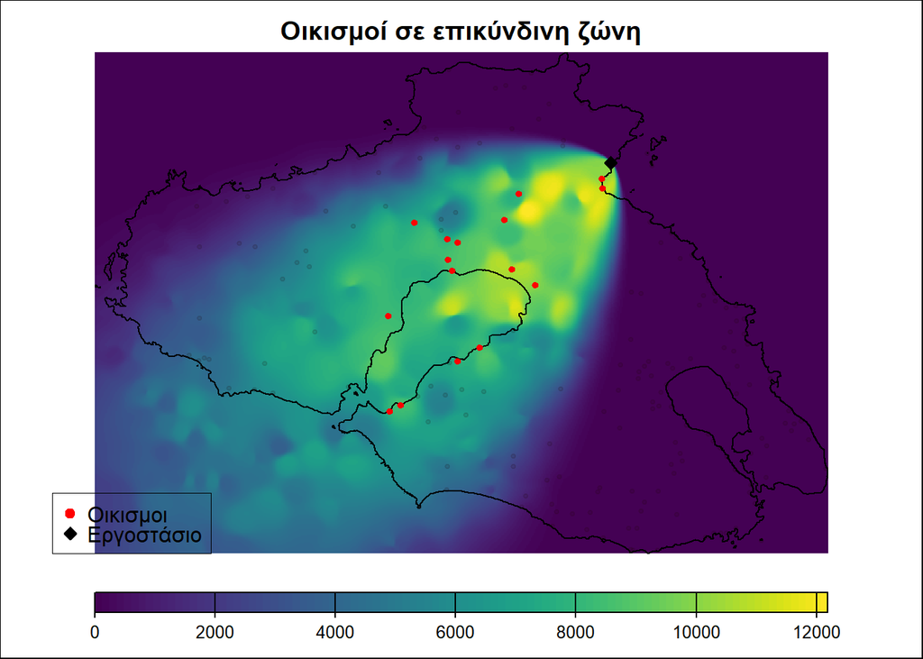

```r
par(mar=c(0,0,0,0) )
terra::plot(ActualPollution, axes=F, box=F, main="Οικισμοί σε επικύνδινη ζώνη", plg=list(loc="bottom") )
plot(st_geometry(acto), main=sprintf("Οικισμοί σε επικύνδινη ζώνη\n>= %s ng",TheThreshold), add=T)
plot(st_geometry(oik),   pch=19, cex=0.5, col=rgb(red=0.1,green=0,blue=0,alpha=0.1), add=T)
plot(st_geometry(oik2),  pch=19, cex=0.6, col="red", add=T)
plot(st_geometry(nuclear), add=T, pch=23, bg="black", col="black")
legend(xpd=T, x='bottomleft', pch=c(19,23), legend=c("Οικισμοι","Εργοστάσιο"),  col=c("red","black"), pt.bg="black", bg=NULL, box.lwd=0)
box()
```

### 1.1 Απάντηση 1ου ερωτήματος

Υπάρχουν 16 οικισμοί με συνολικό πληθυσμό 7294 κατοικων, που επιρεάζονται απο την μολυνση των 7500 ng.

## 2 Ερώτημα 2: Αγροτικές εκτάσεις

Πόση αγροτική έκταση (km2) επηρεάζεται από την έκθεση σε επίπεδο 7500 ng; Πού βρίσκονται αυτές οι περιοχές;

### 2.1 Επιλογή αγροτικών εκτάσεων

Επιλογή μόνο των αγροτικών εκτάσεων απο τα δεδομένα CORINE και μετατρωπη σε πολύγωνο.

```r
corine
```

```
## class       : SpatRaster
## dimensions  : 469, 686, 1  (nrow, ncol, nlyr)
## resolution  : 101.0898, 101.0898  (x, y)
## extent      : 656997.2, 726344.8, 4314945, 4362356  (xmin, xmax, ymin, ymax)
## coord. ref. : +proj=tmerc +lat_0=0 +lon_0=24 +k=0.9996 +x_0=500000 +y_0=0 +ellps=GRS80 +units=m +no_defs
## source      : Corine.tif
## name        : lesvoscorine
## min value   :            1
## max value   :            5
```

Ποιες κατηγορίες περιλαμβάνει το Corine ;

```r
levels(corine)[[1]]
```

```
## [1] ""
```

Ποιο είναι το πλήθος κελιών ανά κατηγορία;

```r
#pol = rasterToPolygons(corine, fun=function(x){x==2})
table(corine[])
```

```
##
##     1     2     3     4     5
##  5934 70333 81951   772  1386
```

Ποιο ειναι το συνολικό εμβαδό των αγροτικών εκτάσεων;

```r
cellSize = cellSize(corine[[1]])[][[1]] / 1000000
ola = sum(table(corine[]))
agr = sum((corine==2)[], na.rm=T)
emvado_agrotika = round((agr*cellSize) ,1)
emvado_agrotika
```

```
## [1] 718.9
```

Το ποσοστό των συνολικών αγροτικών κελιών;

```r
pososto = 100*(agr/ola)
pososto
```

```
## [1] 43.85507
```

```r
res(corine==2) %>% prod() # Εναλακτικός τρόπος υπολογισμού του cell size (m)
```

```
## [1] 10219.15
```

**Χάρτης 2.1**

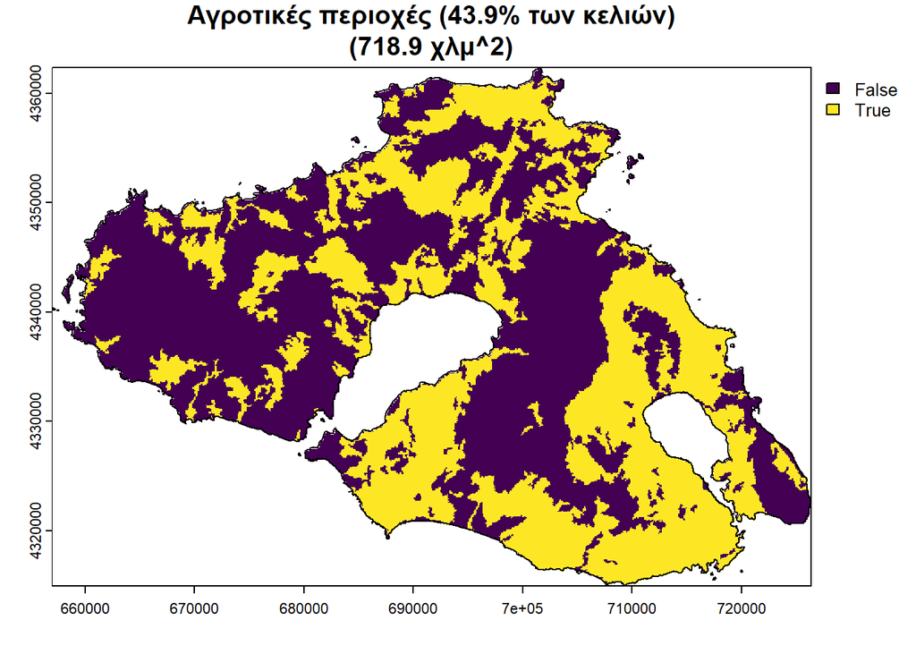

```r
plot( (corine==2), main=sprintf("Αγροτικές περιοχές (%s%% των κελιών)\n(%s χλμ^2)",
                                round(pososto,1), emvado_agrotika ))
plot(st_geometry(acto), add=T )
```

### 2.2 Επιλογή μεγάλης μόλυνσης

Απο το raster της μόλυνσης, επιλογή μονο των κελιών που ειναι πάνω απο το όριο TheThreshold.

```r
bigPolution = ( ActualPollution >= TheThreshold )
#bigPolution = terra::crop(  bigPolution, vect(acto) ) %>% mask(vect(acto))
#bigPolution = classify(bigPolution, cbind(c(TRUE, FALSE), c(1,NA))  )
```

Πόσα κελιά είνα πάνω απο το όριο της μέγάλης μολυνσης;

```r
table(bigPolution[])
```

```
##
##  FALSE   TRUE
## 221839  28161
```

Ποιό είναι το εμβαδό της μεγάλης μολυνσης;

```r
emvado_bigPollution = res(bigPolution) %>% prod()
(emvado_bigPollution)
```

```
## [1] 13109.38
```

Οπτικοποίηση raster μεγάλης μολυνσης:

[figure not shown]

```r
plot(bigPolution, main=sprintf("Μεγάλη μόλυνση (%s χλμ^2)", round(emvado_bigPollution ,1) ), legend=F, col=c(NA,"orange"))
plot(st_geometry(acto), add=T)
plot(st_geometry(nuclear), add=T, pch=23, bg="black", col="black")
legend(x='bottomleft', pch=c(19,23), legend=c("Big Pollution","Plant"),
       col=c("green4","black"), pt.bg="black", bg=NULL, box.lwd=0)
```

### 2.3 Μεγάλη μόλυνση + Αγροτικές εκτάσεις

Οπτικοποίηση των δυο raster:

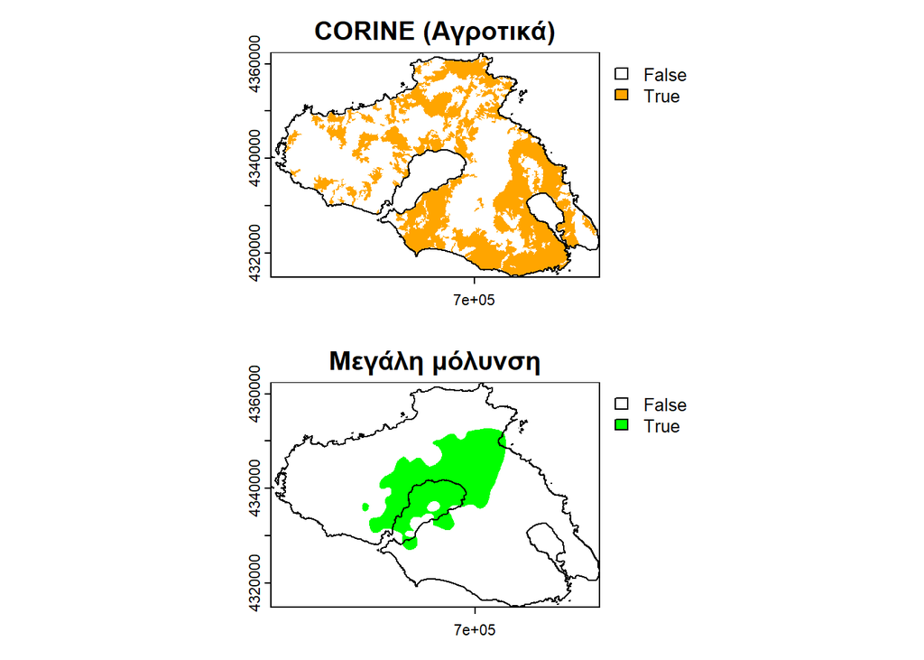

```r
par(mfrow = c(2, 1))
plot(corine==2, main="CORINE (Αγροτικά)", col=c(NA,"orange"))
plot(acto, add=T, col=NA)

plot(bigPolution, main="Μεγάλη μόλυνση", col=c(NA,"green"))
plot(acto, add=T, col=NA)
```

Ποιο ειναι το μέγεθος κελιού των δυο raster (resolution). Είναι διαφορετικό. Αρα θα χρειαστεί να κάνουμε επαναδειγματοληψία (resample), ώστε να έχουμε στη διάθεση μας δυο raster με ίδιο μέγεθος κελιου.

```r
res(corine)
```

```
## [1] 101.0898 101.0898
```

```r
res(bigPolution)
```

```
## [1] 138.5155  94.6420
```

Επαναδειγματοληψία (resample) CORINE στις διαστάσεις του bigPolution (raster μεγάλης μόλυνσης):

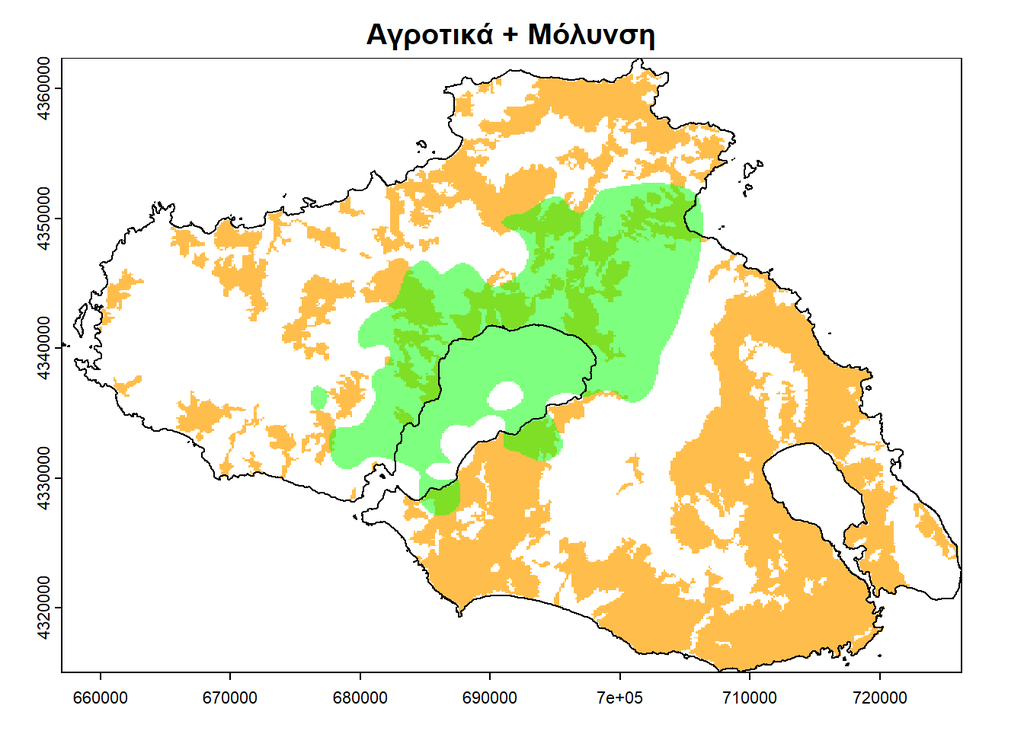

```r
r2 = resample((corine==2), bigPolution, method='near')
plot(r2, main="Αγροτικά + Mόλυνση", col=c(NA,rgb(1,0.64,0,0.7)), legend=F )
plot(bigPolution,  col=c(NA,rgb(0,1,0,0.5)), add=T, legend=F)
plot(st_geometry( acto), add=T, col=NA)
```

Πληροφορίες κελιών του raster: CORINE

```r
table((corine==2)[])
```

```
##
## FALSE  TRUE
## 90043 70333
```

Πληροφορίες κελιών του raster: resampled CORINE

```r
table(r2[])
```

```
##
##     0     1
## 70072 54959
```

Πληροφορίες κελιών του raster: της μεγάλης μολυνσης

```r
table(bigPolution[])
```

```
##
##  FALSE   TRUE
## 221839  28161
```

Συνθεση των δυο raster: Resampled CORINE + μεγάλη μολυνση

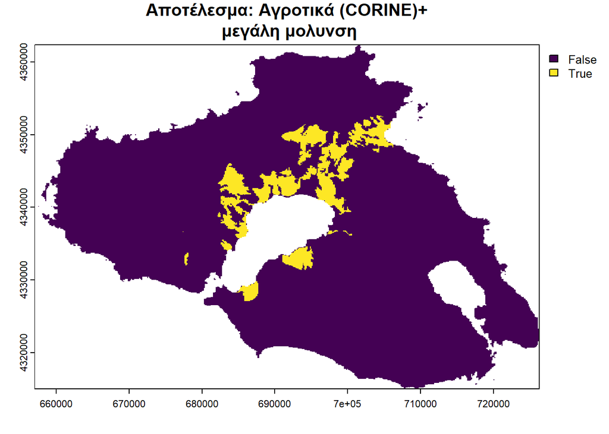

```r
result = (r2 + (bigPolution))==2
plot(result , main="Αποτέλεσμα: Αγροτικά (CORINE)+\n μεγάλη μολυνση")
```

```r
table(result[])
```

```
##
##  FALSE   TRUE
## 116877   8154
```

Πλήθος θετικών κελιών

```r
ncells = sum((result[]==1), na.rm=T)
ncells
```

```
## [1] 8154
```

Εμβαδό του κάθε κελιού

```r
emvado_cell = res(result) %>% prod()
emvado_cell
```

```
## [1] 13109.38
```

Συνολικό εμβαδό των θετικών κελιών

```r
result_emvado = (ncells * emvado_cell)/1000000
result_emvado <- round(result_emvado, 1)
```

### 2.4 Απάντηση 2ου ερωτήματος

Από τα 718.9 χλμ^2 της **συνολικής** αγροτικής εκτασης, υπάρχουν 106.9 χλμ^2 τα οποία βρίσκονται σε περιοχή πάνω απο το όριο των 7500ng μολυνσης. Δηλαδή είναι το 14.9% της **συνολικής** αγροτικής εκτασης.

## 3 Ερώτημα 3: Διοικητικές ενότητες

Ποιες Διοικητικές Ενότητες έχουν μέσο όρο μόλυνσης μεγαλύτερο από το όριο;

- Για κάθε μια απο τις 73 Διοικητικές Ενοτητες, υπολογισμός της μολυνσης εντός του κάθε πολυγώνου:
  - Μέσος Ορος: meanPolution
  - Συνολικό εμβαδό Διοικητής Ενότητας: area

```r
enotites$meanPolution = raster::extract(ActualPollution, enotites, fun=mean )$layer
enotites$area = st_area(enotites)
```

Ποιες Διοικητικές Ενοτητες έχουν ΜΟ μεγαλύτερο απο το όριο των 7500;

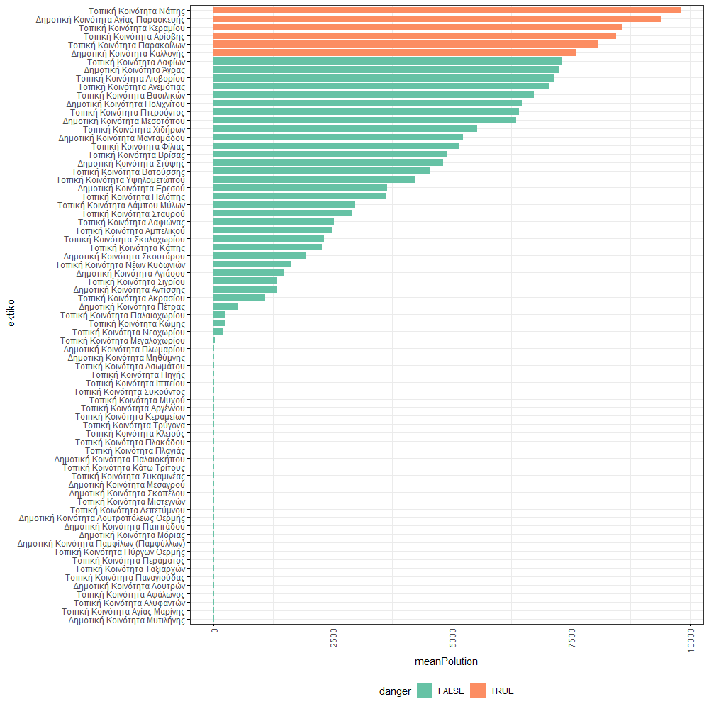

```r
enotites$danger = ifelse(enotites$meanPolution>=TheThreshold, TRUE, FALSE)


ggbarplot(enotites %>% as_tibble(), x = "lektiko", y = "meanPolution",
          fill = "danger",
          color = "danger",
          sort.val = "asc",          # Sort the value in dscending order
          rotate = T,
          x.text.angle = 90,           # Rotate vertically x axis texts
          ggtheme = theme_bw(),
          palette = "Set2", legend = "bottom"
)
```

Απλοί θεματικοί χάρτες

**Χάρτης 3.1**

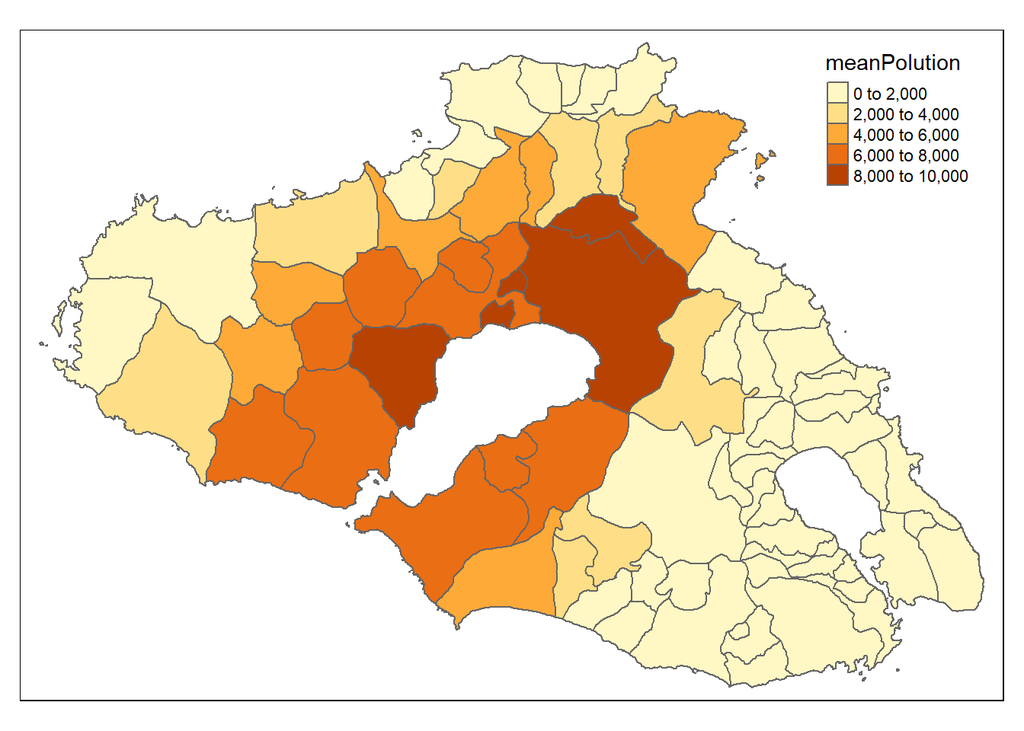

```r
qtm(enotites, fill = "meanPolution" )+ tm_layout(legend.position = c("right", "top")  )
```

**Χάρτης 3.2**

```r
qtm(enotites, fill = "danger" )+ tm_layout(legend.position = c("right", "top")
)
```

[figure not shown]

### 3.1 Απάντηση 3ου ερωτήματος

Υπάρχουν 6 Διοικητικές Ενότητες με μεσο όρο μεγαλύτερο απο το όριο 7500.

## 4 Πηγαίος Κώδικας

```r
# "
# getwd()
# setwd('d:\\Users\\geo21071\\Downloads\\data')
# "
# library(sf)
# library(terra)
# library(dplyr)
# library(tmap)
# library(ggpubr)
#
# st_layers("Exported2/Vectors.gpkg")
#
# acto = st_read("Exported2/Vectors.gpkg", layer="acto", quiet = T )
# oik = st_read("Exported2/Vectors.gpkg", layer="oik", quiet = T )
# nuclear = st_read("Exported2/Vectors.gpkg", layer="nuclear", quiet = T )
# #stations = st_read("Exported2/Vectors.gpkg", layer="stations", quiet = T )
# enotites= st_read("Exported2/Vectors.gpkg", layer="enotites", quiet = T )
#
# corine = rast("Exported2/Corine.tif")
# dem = rast("Exported2/dem.tif") # Δεν θα χρησημοποιηθεί
# ActualPollution = rast("Exported2/ActualPollution.tif")
#
# par(mar=c(1,1,1,3) )
# mycol = c("grey30","orange","green","purple","blue")
# plot(corine, legend = T, col = mycol)
# #legend(x='bottomleft', xpd=T, inset=c(0.98, 0.40),
# #       legend=levels(corine)[[1]]$value,
# #       fill = mycol,bg =NULL, box.lwd = 0)
# plot(st_geometry(acto), add=T, border="grey40")
#
# par(mar=c(1,1,1,1) )
# plot(st_geometry(oik), main="Towns", pch=19, cex=0.6, col="red")
# plot(st_geometry(acto), add=T, border="grey40")
# plot(st_geometry(nuclear), add=T, pch=23, col="black", bg="black"  )
# legend(x='bottomleft', pch=c(19,23), legend=c("Towns","Plant"),
#        col=c("red","black"), pt.bg="black", bg=NULL, box.lwd=0)
# box()
#
# plot((ActualPollution), main="Actual Pollution")
# plot(st_geometry(acto), add=T, border="grey40")
# #plot(st_geometry(stations), add=T, pch=6, col="blue")
# plot(st_geometry(nuclear), add=T, pch=23, col="black", bg="black")
#
# legend(x='bottomleft', xpd=T, inset=c(0.10, 0.03),
#        pch=c(6,23),
#        legend=c("Nuclear Plant"),
#        col = c("black"), pt.bg="black",
#        bg =NULL, box.lwd = 0)
#
# TheThreshold=7500
# plot(st_geometry(enotites), main="Administrative sub-units", border="grey40" )
# plot(st_geometry(acto), add=T  )
# text(st_coordinates(st_centroid( enotites)), label=enotites$kalcode,  cex=0.4,col="blue" ) #
# box()
#
# oik$ActualPollution = terra::extract(ActualPollution, oik, ID=F)[[1]]
# oik2 = subset(oik, ActualPollution >= TheThreshold)
# dim(oik2)
#
# sum(oik2$pop2011)
#
# par(mar=c(1,1,2,1) )
# plot(st_geometry(acto), main=sprintf("Οικισμοί σε επικύνδινη ζώνη\n>= %s ng",TheThreshold) )
# plot(st_geometry(oik2), main="Towns", pch=19, cex=0.6, col="red", add=T)
# plot(st_geometry(nuclear), add=T, pch=23, bg="black", col="black")
# legend(x='bottomleft', pch=c(19,23), legend=c("Οικισμοι","Εργοστάσιο"),
#        col=c("red","black"), pt.bg="black", bg=NULL, box.lwd=0)
# box()
#
# par(mar=c(0,0,0,0) )
# terra::plot(ActualPollution, axes=F, box=F, main="Οικισμοί σε επικύνδινη ζώνη", plg=list(loc="bottom") )
# plot(st_geometry(acto), main=sprintf("Οικισμοί σε επικύνδινη ζώνη\n>= %s ng",TheThreshold), add=T)
# plot(st_geometry(oik),   pch=19, cex=0.5, col=rgb(red=0.1,green=0,blue=0,alpha=0.1), add=T)
# plot(st_geometry(oik2),  pch=19, cex=0.6, col="red", add=T)
# plot(st_geometry(nuclear), add=T, pch=23, bg="black", col="black")
# legend(xpd=T, x='bottomleft', pch=c(19,23), legend=c("Οικισμοι","Εργοστάσιο"),  col=c("red","black"), pt.bg="black", bg=NULL, box.lwd=0)
# box()
#
# corine
#
# levels(corine)[[1]]
#
# #pol = rasterToPolygons(corine, fun=function(x){x==2})
# table(corine[])
#
# cellSize = cellSize(corine[[1]])[][[1]] / 1000000
# ola = sum(table(corine[]))
# agr = sum((corine==2)[], na.rm=T)
# emvado_agrotika = round((agr*cellSize) ,1)
# emvado_agrotika
#
# pososto = 100*(agr/ola)
# pososto
#
# res(corine==2) %>% prod() # Εναλακτικός τρόπος υπολογισμού του cell size (m)
#
# plot( (corine==2), main=sprintf("Αγροτικές περιοχές (%s%% των κελιών)\n(%s χλμ^2)",
#                                 round(pososto,1), emvado_agrotika ))
# plot(st_geometry(acto), add=T )
#
# bigPolution = ( ActualPollution >= TheThreshold )
# #bigPolution = terra::crop(  bigPolution, vect(acto) ) %>% mask(vect(acto))
# #bigPolution = classify(bigPolution, cbind(c(TRUE, FALSE), c(1,NA))  )
#
# table(bigPolution[])
#
# emvado_bigPollution = res(bigPolution) %>% prod()
# (emvado_bigPollution)
#
#
# plot(bigPolution, main=sprintf("Μεγάλη μόλυνση (%s χλμ^2)", round(emvado_bigPollution ,1) ), legend=F, col=c(NA,"orange"))
# plot(st_geometry(acto), add=T)
# plot(st_geometry(nuclear), add=T, pch=23, bg="black", col="black")
# legend(x='bottomleft', pch=c(19,23), legend=c("Big Pollution","Plant"),
#        col=c("green4","black"), pt.bg="black", bg=NULL, box.lwd=0)
#
# par(mfrow = c(2, 1))
# plot(corine==2, main="CORINE (Αγροτικά)", col=c(NA,"orange"))
# plot(acto, add=T, col=NA)
#
# plot(bigPolution, main="Μεγάλη μόλυνση", col=c(NA,"green"))
# plot(acto, add=T, col=NA)
#
# res(corine)
# res(bigPolution)
#
#
# r2 = resample((corine==2), bigPolution, method='near')
# plot(r2, main="Αγροτικά + Mόλυνση", col=c(NA,rgb(1,0.64,0,0.7)), legend=F )
# plot(bigPolution,  col=c(NA,rgb(0,1,0,0.5)), add=T, legend=F)
# plot(st_geometry( acto), add=T, col=NA)
#
# table((corine==2)[])
# table(r2[])
# table(bigPolution[])
# result = (r2 + (bigPolution))==2
# plot(result , main="Αποτέλεσμα: Αγροτικά (CORINE)+\n μεγάλη μολυνση")
# table(result[])
# ncells = sum((result[]==1), na.rm=T)
# ncells
# emvado_cell = res(result) %>% prod()
# emvado_cell
#
# result_emvado = (ncells * emvado_cell)/1000
# result_emvado
#
#
# enotites$meanPolution = raster::extract(ActualPollution, enotites, fun=mean )$layer
# enotites$area = st_area(enotites)
# enotites$danger = ifelse(enotites$meanPolution>=TheThreshold, TRUE, FALSE)
#
#
# ggbarplot(enotites %>% as_tibble(), x = "lektiko", y = "meanPolution",
#           fill = "danger",
#           color = "danger",
#           sort.val = "asc",          # Sort the value in dscending order
#           rotate = T,
#           x.text.angle = 90,           # Rotate vertically x axis texts
#           ggtheme = theme_bw(),
#           palette = "Set2", legend = "bottom"
# )
#
# qtm(enotites, fill = "meanPolution" )+ tm_layout(legend.position = c("right", "top")  )
# qtm(enotites, fill = "danger" )+ tm_layout(legend.position = c("right", "top")  )
```

## 5 Βιβλιογραφία

- Καβρουδάκης, Δ. (2022) ΠΠΣ Γεωγραφική Ανάλυση (ΓΕΟ 302).
  - Διαθέσιμο στο: [Open eClass, Πανεπιστήμιο Αιγαίου](https://eclass.aegean.gr/courses/GEO157/)
  - (Πρόσβαση: 10/12/2024).

[figure not shown]